# An approach to predict Human Activity Recognition

Tobias Springer

September 2015

### Introduction

Using devices such as Jawbone Up, Nike FuelBand, and Fitbit it is now possible to collect a large amount of data about personal activity relatively inexpensively. These type of devices are part of the quantified self movement – a group of enthusiasts who take measurements about themselves regularly to improve their health, to find patterns in their behavior, or because they are tech geeks. One thing that people regularly do is quantify how much of a particular activity they do, but they rarely quantify how well they do it. In this project, your goal will be to use data from accelerometers on the belt, forearm, arm, and dumbell of 6 participants. They were asked to perform barbell lifts correctly and incorrectly in 5 different ways. More information is available from the [website](http://groupware.les.inf.puc-rio.br/har) (see the section on the Weight Lifting Exercise Dataset).

### Remark on model creation

During the process of building a predictive model, we will apply cross-validation by splitting the offered training data further into a *local* training and a *local* test data set. This is feasible due to the large size of the given training data. After learning a model on the *local* training data and testing its performance on the *local* test data, we will apply the model on the given test data.

Furthermore, due to the larger number of data, we can expect the *out-of-sample error* to be somewhat close to the *in-sample error*, at least our model should strive for that to happen. The out-of-sample error is shown as the accuracy when applying the *confusionMatrix* command in *R*, which we will use for verifying the model accuracy.

### Remark on the classifier variable

According to [Veloso et al.](http://groupware.les.inf.puc-rio.br/public/papers/2013.Velloso.QAR-WLE.pdf), “participants were asked to perform one set of 10 repetitions of the Unilateral Dumbbell Biceps Curl in five different fashions: exactly according to the specification **(Class A)**, throwing the elbows to the front **(Class B)**, lifting the dumbbell only halfway **(Class C)**, lowering the dumbbell only halfway **(Class D)** and throwing the hips to the front **(Class E)**. Class A corresponds to the specified execution of the exercise, while the other 4 classes correspond to common mistakes.”

### Data Processing

The data required for this analysis is divided into two sets, one [training data set](https://d396qusza40orc.cloudfront.net/predmachlearn/pml-training.csv), and the [testing data set](https://d396qusza40orc.cloudfront.net/predmachlearn/pml-testing.csv).

First of all, we import (if that has not happened thus far) the data from the [website](https://d396qusza40orc.cloudfront.net/predmachlearn/pml-training.csv) into the working directory and do some quick cleaning by replacing all missing values with *NA*’s:

```r
# Download training data if not happened
if (!file.exists("training.csv")){
   fileURL1<-"https://d396qusza40orc.cloudfront.net/predmachlearn/pml-training.csv"
   download.file(fileURL1,destfile="training.csv",method="curl")
}
trainData<-read.csv("training.csv",sep=",",header=TRUE, na.strings=c("NA", ""))
if (!file.exists("testing.csv")){
   fileURL1<-"https://d396qusza40orc.cloudfront.net/predmachlearn/pml-testing.csv"
   download.file(fileURL1,destfile="testing.csv",method="curl")
}
testData<-read.csv("testing.csv",sep=",",header=TRUE, na.strings=c("NA", ""))
```

[output not shown]

Moreover, by applying

```r
omitColumns <- function(T) {
  subset(T[,colSums(is.na(T)) == 0],
         select = -c(X, user_name, raw_timestamp_part_1, raw_timestamp_part_2,
                     cvtd_timestamp, new_window, num_window))
  }
trainData <- omitColumns(trainData)
testData <- omitColumns(testData)
```

we omit all columns that do not contain any values as well as unnecessary info variables, leaving us with

```r
names(trainData)
```

```
##  [1] "roll_belt"            "pitch_belt"           "yaw_belt"
##  [4] "total_accel_belt"     "gyros_belt_x"         "gyros_belt_y"
##  [7] "gyros_belt_z"         "accel_belt_x"         "accel_belt_y"
## [10] "accel_belt_z"         "magnet_belt_x"        "magnet_belt_y"
## [13] "magnet_belt_z"        "roll_arm"             "pitch_arm"
## [16] "yaw_arm"              "total_accel_arm"      "gyros_arm_x"
## [19] "gyros_arm_y"          "gyros_arm_z"          "accel_arm_x"
## [22] "accel_arm_y"          "accel_arm_z"          "magnet_arm_x"
## [25] "magnet_arm_y"         "magnet_arm_z"         "roll_dumbbell"
## [28] "pitch_dumbbell"       "yaw_dumbbell"         "total_accel_dumbbell"
## [31] "gyros_dumbbell_x"     "gyros_dumbbell_y"     "gyros_dumbbell_z"
## [34] "accel_dumbbell_x"     "accel_dumbbell_y"     "accel_dumbbell_z"
## [37] "magnet_dumbbell_x"    "magnet_dumbbell_y"    "magnet_dumbbell_z"
## [40] "roll_forearm"         "pitch_forearm"        "yaw_forearm"
## [43] "total_accel_forearm"  "gyros_forearm_x"      "gyros_forearm_y"
## [46] "gyros_forearm_z"      "accel_forearm_x"      "accel_forearm_y"
## [49] "accel_forearm_z"      "magnet_forearm_x"     "magnet_forearm_y"
## [52] "magnet_forearm_z"     "classe"
```

as variables. This leads to a large training data set having 19622 observations stored in rows and 53 variables, the most interesting for us being the *classe* variable. In comparison, the test data contains only contains 20 cases – as mentioned above.

Hence, we have sufficient data to partition the *global* training set further into two subsets, one *local* training set for building the model and a *local* test set for evaluation of the model before using it as a predictor for the *global* test set:

```r
set.seed(4711)
furtherSamples <- createDataPartition(y=trainData$classe, p=0.6, list=FALSE)
localTrain <- trainData[furtherSamples,]
localTest <- trainData[-furtherSamples,]
```

where *localTrain* consists of 11776 cases and *localTest* of 7846.

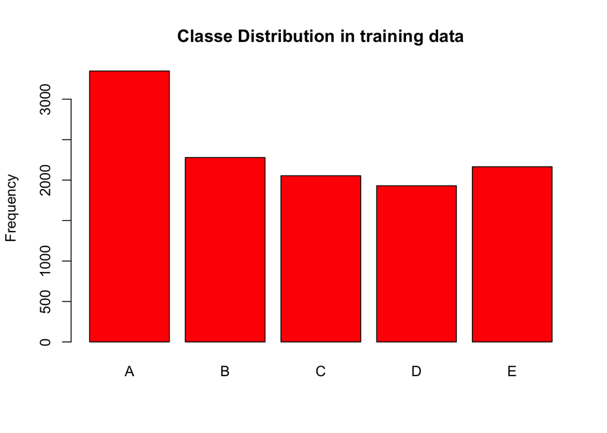

```r
plot(localTrain$classe, col="red", main="Classe Distribution in training data", xlab="", ylab="Frequency")
```

As can be seen from the figure, the data contains an increased number of *correct* executions of the given physical exercise compared to the four *wrong* ones.

### Prediction model

First and simplest approach is to apply a decision tree in order to predict values in future.

```r
decTreeModel <- rpart(classe ~ ., data = localTrain, method="class")
```

Now, let us take a look at the emerging tree

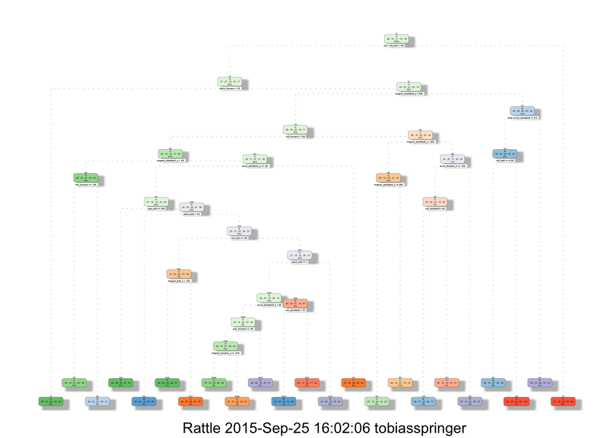

```r
fancyRpartPlot(decTreeModel)
```

and evaluate the approach after predicting the values in the *local* test data:

```r
predictDecTree <- predict(decTreeModel, localTest, type = "class")
confusionMatrix(predictDecTree, localTest$classe)
```

```
## Confusion Matrix and Statistics
##
##           Reference
## Prediction    A    B    C    D    E
##          A 2007  269   37   83   56
##          B   82  855   70  105  118
##          C   48  188 1094  191  156
##          D   64  100   80  796   74
##          E   31  106   87  111 1038
##
## Overall Statistics
##
##                Accuracy : 0.738
##                  95% CI : (0.7281, 0.7477)
##     No Information Rate : 0.2845
##     P-Value [Acc > NIR] : < 2.2e-16
##
##                   Kappa : 0.6675
##  Mcnemar's Test P-Value : < 2.2e-16
##
## Statistics by Class:
##
##                      Class: A Class: B Class: C Class: D Class: E
## Sensitivity            0.8992   0.5632   0.7997   0.6190   0.7198
## Specificity            0.9207   0.9407   0.9100   0.9515   0.9477
## Pos Pred Value         0.8185   0.6951   0.6524   0.7145   0.7560
## Neg Pred Value         0.9583   0.8998   0.9556   0.9272   0.9376
## Prevalence             0.2845   0.1935   0.1744   0.1639   0.1838
## Detection Rate         0.2558   0.1090   0.1394   0.1015   0.1323
## Detection Prevalence   0.3125   0.1568   0.2137   0.1420   0.1750
## Balanced Accuracy      0.9100   0.7520   0.8549   0.7852   0.8338
```

Well, the accuracy in this case is rather poor! Hence, we take a second approach by applying random forests:

```r
randForestModel <- randomForest(classe ~. , data=localTrain, method="class")
predictRandForest <- predict(randForestModel, localTest, type = "class")
confusionMatrix(predictRandForest, localTest$classe)
```

```
## Confusion Matrix and Statistics
##
##           Reference
## Prediction    A    B    C    D    E
##          A 2229    6    0    0    0
##          B    2 1512   13    0    0
##          C    0    0 1351   24    0
##          D    0    0    4 1262   10
##          E    1    0    0    0 1432
##
## Overall Statistics
##
##                Accuracy : 0.9924
##                  95% CI : (0.9902, 0.9942)
##     No Information Rate : 0.2845
##     P-Value [Acc > NIR] : < 2.2e-16
##
##                   Kappa : 0.9903
##  Mcnemar's Test P-Value : NA
##
## Statistics by Class:
##
##                      Class: A Class: B Class: C Class: D Class: E
## Sensitivity            0.9987   0.9960   0.9876   0.9813   0.9931
## Specificity            0.9989   0.9976   0.9963   0.9979   0.9998
## Pos Pred Value         0.9973   0.9902   0.9825   0.9890   0.9993
## Neg Pred Value         0.9995   0.9991   0.9974   0.9963   0.9984
## Prevalence             0.2845   0.1935   0.1744   0.1639   0.1838
## Detection Rate         0.2841   0.1927   0.1722   0.1608   0.1825
## Detection Prevalence   0.2849   0.1946   0.1752   0.1626   0.1826
## Balanced Accuracy      0.9988   0.9968   0.9919   0.9896   0.9965
```

Due to the fact that this model indicates high accuracy, we can conclude that it will very likely perform well on the 20 remaining test subjects.